# RfaH

## Figure 5: Per-residue ΔΔG fold-preference contribution

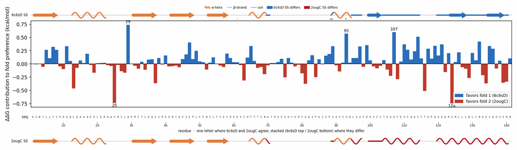

**More figures**

## Figure 6: Deep-MSA contact map panel / Best clusters contact map panel

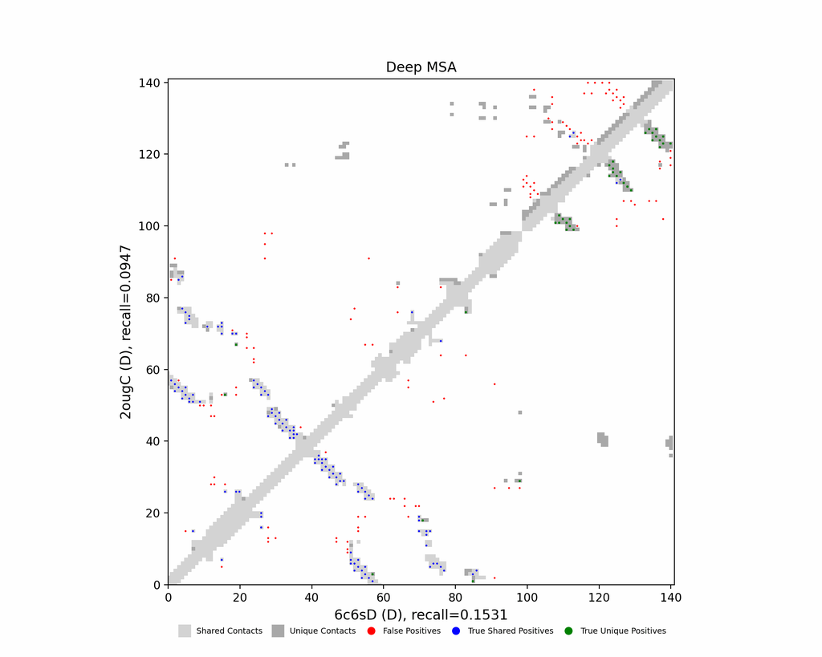

Deep-MSA contact map panel

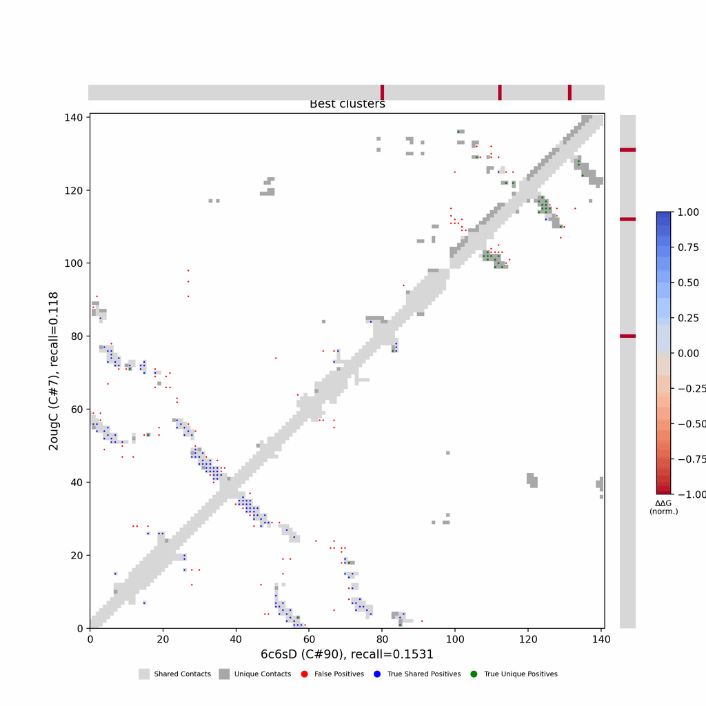

Best clusters contact map panel

## Figure 7: All clusters contact-map mosaic (small multiples).

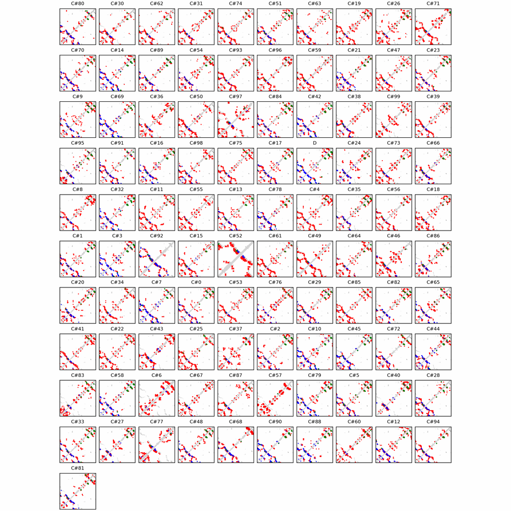

## Figure 8: Phylo null: tree with shuffled cluster fold labels.

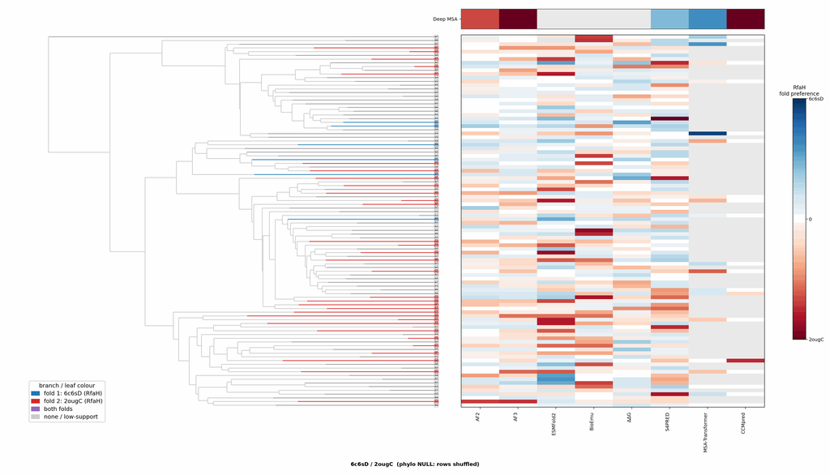

## Cluster metrics table

Per-cluster metrics underlying the figures above.

| cluster | n | neff | AF2_TM1 | AF2_TM2 | AF3_TM1 | AF3_TM2 | RE-MSAT-COM | RE-MSAT1 | RE-MSAT2 | ESM_SEQIDS | ESM_TM1 | ESM_TM2 | ΔΔG_Bias | ΔΔG_Bias_std | ΔΔG_frac_F1 | Boltz2_pref | S4PRED_pref | CCMpred_pref | BioEmu_pref |
| --- | --- | --- | --- | --- | --- | --- | --- | --- | --- | --- | --- | --- | --- | --- | --- | --- | --- | --- | --- |
| Deep | - | - | 0.56 | 0.74 | 0.56 | 0.9 | 0.44 | 0.52 | 0.39 | - | - | - | - | - | - | - | 0.12 | -0.01 | - |
| 000 | 719.0 | 449.0 | 0.32 | 0.4 | 0.43 | 0.57 | 0.19 | 0.22 | 0.2 | 007; 007; 001; 001; 002; 002; 006; 006; 003; 003 | 0.55 ± 0.01 | 0.65 ± 0.03 | 3.48 | 2.9 | 0.9 | -0.07 | 0.02 | -0.0 | -0.01 |
| 001 | 448.0 | 313.0 | 0.54 | 0.62 | 0.55 | 0.72 | 0.2 | 0.23 | 0.18 | 004; 005; 005; 004; 001; 003; 006; 001; 003; 002 | 0.55 ± 0.01 | 0.64 ± 0.05 | 4.46 | 4.26 | 0.8 | -0.06 | 0.03 | 0.0 | -0.05 |
| 002 | 433.0 | 235.0 | 0.42 | 0.49 | 0.52 | 0.64 | 0.18 | 0.17 | 0.19 | 004; 004; 001; 001; 006; 003; 003; 006; 002; 002 | 0.55 ± 0.01 | 0.68 ± 0.08 | 1.27 | 3.03 | 0.6 | -0.1 | 0.18 | 0.0 | -0.06 |
| 003 | 346.0 | 144.0 | 0.37 | 0.49 | 0.5 | 0.67 | 0.45 | 0.49 | 0.38 | 001; 002; 001; 002; 005; 005; 003; 006; 003; 006 | 0.54 ± 0.01 | 0.65 ± 0.03 | 1.51 | 3.72 | 0.6 | -0.07 | 0.1 | 0.0 | -0.07 |
| 004 | 345.0 | 286.0 | 0.43 | 0.47 | 0.44 | 0.45 | 0.01 | 0.01 | 0.04 | 001; 005; 005; 001; 004; 004; 009; 002; 002; 009 | 0.56 ± 0.01 | 0.64 ± 0.01 | 4.66 | 2.33 | 0.9 | -0.06 | -0.02 | -0.0 | -0.06 |
| 005 | 304.0 | 240.0 | 0.24 | 0.26 | 0.36 | 0.37 | 0.17 | 0.18 | 0.19 | 002; 002; 001; 003; 001; 003; 005; 005; 006; 006 | 0.55 ± 0.01 | 0.61 ± 0.02 | 6.77 | 4.62 | 0.9 | -0.03 | -0.11 | 0.0 | -0.03 |
| 006 | 282.0 | 144.0 | 0.2 | 0.25 | 0.21 | 0.26 | 0.02 | 0.02 | 0.02 | 001; 004; 004; 001; 008; 008; 006; 006; 003; 003 | 0.55 ± 0.02 | 0.64 ± 0.02 | 2.78 | 2.71 | 0.9 | 0.0 | -0.02 | 0.0 | -0.04 |
| 007 | 246.0 | 111.0 | 0.4 | 0.46 | 0.49 | 0.57 | 0.52 | 0.43 | 0.46 | 001; 001; 005; 005; 003; 004; 004; 003; 010; 010 | 0.55 ± 0.02 | 0.64 ± 0.02 | 3.66 | 1.95 | 1.0 | -0.04 | 0.1 | 0.0 | -0.07 |
| 008 | 223.0 | 131.0 | 0.29 | 0.36 | 0.47 | 0.54 | 0.04 | 0.03 | 0.06 | 004; 004; 002; 002; 001; 001; 003; 003; 005; 005 | 0.54 ± 0.02 | 0.64 ± 0.05 | 5.12 | 2.91 | 0.9 | -0.04 | 0.12 | 0.0 | -0.04 |
| 009 | 223.0 | 139.0 | 0.39 | 0.46 | 0.53 | 0.81 | 0.18 | 0.19 | 0.16 | 009; 009; 006; 006; 003; 003; 001; 001; 010; 002 | 0.52 ± 0.03 | 0.63 ± 0.02 | 3.76 | 3.25 | 0.8 | -0.04 | 0.12 | 0.0 | -0.08 |
| 010 | 203.0 | 138.0 | 0.36 | 0.49 | 0.51 | 0.59 | 0.42 | 0.36 | 0.33 | 004; 004; 005; 005; 003; 003; 002; 002; 001; 001 | 0.55 ± 0.03 | 0.61 ± 0.02 | 6.0 | 4.21 | 1.0 | -0.07 | 0.14 | 0.0 | -0.06 |
| 011 | 186.0 | 105.0 | 0.45 | 0.5 | 0.52 | 0.64 | 0.03 | 0.04 | 0.04 | 010; 010; 003; 003; 001; 001; 002; 002; 009; 009 | 0.51 ± 0.03 | 0.60 ± 0.03 | 2.45 | 2.21 | 0.9 | -0.09 | 0.06 | 0.0 | -0.06 |
| 012 | 183.0 | 127.0 | 0.46 | 0.55 | 0.54 | 0.68 | 0.32 | 0.26 | 0.26 | 007; 002; 007; 002; 005; 005; 001; 001; 006; 006 | 0.56 ± 0.01 | 0.66 ± 0.02 | 3.57 | 2.64 | 0.9 | -0.14 | 0.1 | 0.0 | -0.08 |
| 013 | 177.0 | 125.0 | 0.31 | 0.36 | 0.46 | 0.56 | 0.18 | 0.18 | 0.16 | 002; 002; 001; 007; 006; 005; 006; 007; 005; 003 | 0.55 ± 0.01 | 0.66 ± 0.04 | 1.55 | 3.04 | 0.8 | -0.05 | 0.17 | 0.0 | -0.06 |
| 014 | 174.0 | 113.0 | 0.41 | 0.54 | 0.48 | 0.57 | 0.4 | 0.42 | 0.32 | 001; 001; 002; 002; 003; 003; 005; 005; 004; 004 | 0.54 ± 0.04 | 0.62 ± 0.07 | 4.69 | 3.63 | 0.9 | -0.13 | 0.19 | 0.0 | -0.1 |
| 015 | 153.0 | 93.0 | 0.3 | 0.33 | 0.51 | 0.64 | 0.03 | 0.02 | 0.03 | 001; 006; 006; 004; 010; 001; 004; 010; 007; 005 | 0.54 ± 0.01 | 0.63 ± 0.02 | 4.74 | 3.48 | 1.0 | -0.05 | -0.13 | 0.0 | -0.04 |
| 016 | 150.0 | 108.0 | 0.42 | 0.56 | 0.48 | 0.54 | 0.26 | 0.23 | 0.19 | 004; 004; 001; 001; 006; 006; 005; 005; 008; 008 | 0.53 ± 0.03 | 0.64 ± 0.05 | 3.07 | 2.19 | 0.9 | -0.04 | 0.09 | 0.0 | -0.1 |
| 017 | 147.0 | 108.0 | 0.28 | 0.38 | 0.43 | 0.5 | 0.16 | 0.14 | 0.14 | 003; 003; 005; 005; 002; 007; 007; 002; 001; 001 | 0.55 ± 0.01 | 0.67 ± 0.05 | 3.09 | 2.69 | 0.8 | -0.05 | 0.09 | 0.0 | -0.05 |
| 018 | 143.0 | 112.0 | 0.22 | 0.27 | 0.54 | 0.55 | 0.02 | 0.02 | 0.03 | 002; 002; 004; 004; 001; 005; 001; 005; 007; 006 | 0.56 ± 0.01 | 0.66 ± 0.03 | 3.3 | 3.22 | 0.8 | -0.03 | 0.15 | 0.0 | -0.04 |
| 019 | 140.0 | 89.0 | 0.55 | 0.63 | 0.58 | 0.64 | 0.02 | 0.01 | 0.04 | - | - | - | 3.48 | 4.1 | 0.7 | -0.02 | 0.17 | - | -0.02 |
| 020 | 139.0 | 53.0 | 0.46 | 0.59 | 0.53 | 0.72 | 0.11 | 0.06 | 0.09 | - | - | - | 3.54 | 2.35 | 1.0 | -0.06 | 0.11 | - | -0.08 |
| 021 | 131.0 | 91.0 | 0.46 | 0.6 | 0.45 | 0.55 | 0.34 | 0.28 | 0.27 | - | - | - | 4.17 | 3.56 | 1.0 | -0.09 | 0.02 | - | -0.1 |
| 022 | 130.0 | 107.0 | 0.22 | 0.23 | 0.23 | 0.28 | 0.02 | 0.02 | 0.05 | - | - | - | 2.45 | 2.63 | 0.9 | -0.02 | 0.01 | - | -0.02 |
| 023 | 130.0 | 87.0 | 0.53 | 0.67 | 0.54 | 0.72 | 0.14 | 0.18 | 0.14 | - | - | - | 3.23 | 3.22 | 0.8 | -0.0 | 0.16 | - | -0.06 |
| 024 | 125.0 | 57.0 | 0.46 | 0.52 | 0.41 | 0.46 | 0.2 | 0.12 | 0.14 | - | - | - | 2.36 | 2.18 | 0.8 | -0.09 | 0.16 | - | -0.08 |
| 025 | 122.0 | 91.0 | 0.22 | 0.29 | 0.41 | 0.52 | 0.01 | 0.01 | 0.03 | - | - | - | 3.09 | 3.04 | 0.8 | -0.15 | 0.16 | - | -0.04 |
| 026 | 121.0 | 71.0 | 0.35 | 0.44 | 0.29 | 0.34 | 0.03 | 0.04 | 0.03 | - | - | - | 3.78 | 3.41 | 0.9 | -0.05 | 0.16 | - | -0.06 |
| 027 | 121.0 | 44.0 | 0.34 | 0.41 | 0.52 | 0.72 | 0.11 | 0.08 | 0.09 | - | - | - | 1.04 | 2.72 | 0.5 | -0.04 | 0.12 | - | -0.06 |
| 028 | 115.0 | 98.0 | 0.58 | 0.76 | 0.58 | 0.73 | 0.22 | 0.17 | 0.2 | - | - | - | 3.79 | 3.96 | 0.9 | -0.01 | 0.01 | - | -0.02 |

[output cut: 71 more lines]